Supposing we have a diploid model organism in the sense of Chapter 1 of Edwards, *Foundations of Mathematical Genetics* (non-overlapping generations, random union of gametes, no developmental effects and so on), we can use the script https://github.com/amatrhr/g-remladp/blob/master/simulate_funcs_HEDOSE_0.6.R to simulate individuals’ phased genotypes by first simulating their parents’ gametes.

This page describes the process for one locus.

# Simulating one locus: ideal *G-REMLadp* model

## Process

### Gametes

- The locus has a minor allele with frequency $p$, hence an individual gamete is modeled as a draw from the Bernoulli($p$) distribution; note $q = 1-p$
- In simulations, draw $n$ maternal gametes as $n$ draws from the Bernoulli($p$) and store them in the vector $\mathbf{g}_{mo}$, coding minor alleles as 1s and major alleles as 0s
- Permute the indices of $\mathbf{g}_{mo}$ to generate a vector of paternal gametes, $\mathbf{g}_{fa}$
  - This way, the proportion of minor alleles is exactly equal in both maternal and paternal gamete vectors
  - Suppose the sample is large enough that the sample proportion of minor alleles in each vector of gametes is expected to differ from the true minor allele frequency by an arbitrary negligable amount so that $\mathbf{g}_{mo}^\prime\mathbf{g}_{mo} = \mathbf{g}_{fa}^\prime\mathbf{g}_{fa} \doteq np$ and our abuses of notation by interchanging proportions and probabilities are venal sins

### Phased genotype

- This is a four-category multinomial variable. For individual $i$, in $1\dots n$
  1. $aa$, or Homozygous major: $g_{mo,\, i} = g_{fa,\,i} = 0$ with probability $q^2$
  2. $a_{mo}A_{fa}$, or Maternal-major heterozygote: $g_{mo,\,i} = 0;\;g_{fa,\,i} = 1$ with probability $pq$
  3. $A_{mo}a_{fa}$, or Paternal-major heterozygote: $g_{mo,\,i} = 1;\;g_{fa,\, i} = 0$ with probability $pq$
  4. $AA$, or Homozygous minor: $g_{mo,\,i} = g_{fa,\, i} = 1$ with probability $p^2$
- Represent this using three codings: additive, parent-of-origin, dominance

### Additive coding: $\mathbf{x}_{A}$

- This is the count of minor alleles for each individual: $\mathbf{x}_{A} = \mathbf{g}_{fa} + \mathbf{g}_{mo}$
- An $n$-vector consisting of (roughly) $nq^2$ 0’s, $2npq$ 1’s and $np^2$ 2’s

### Dominance coding $\mathbf{x}_{\Delta}$

- From [Zhu et al 2015](https://www.ncbi.nlm.nih.gov/pmc/articles/PMC4375616/)
- Code homozygous-major individuals as 0; heterozygotes as $2p$, homozygous-minor individuals as $4p -2$
- $\mathbf{x}_\Delta = 2p\mathbf{x}_{A} - 2\mathcal{I}\left(\mathbf{x}_A > 1\right)$
  - Where $\mathcal{I}\left(.\right)$ is the indicator function.
- The additive and dominance codings have 0 covariance but are not orthogonal unless centred; their cross product is equal to the product of the means of $\mathbf{x}_A$ and $\mathbf{x}_\Delta$
  - $\mathbf{x}_\Delta^\prime\mathbf{x}_{A} = 2p\left(2pq + 4p^2\right) - 2\left(2p^2\right) = 2p \times 2p^2$

## `simulate_funcs_HEDOSE.R` and `lrt_sim_HEDOSE.R::heSim()`

These are helper functions within larger functions and aren’t run on their own in practice, but it is helpful to look into them to see how data are generated.

### Generating genotype codings

#### Simulating gametes

- Maternal gametes are generated in`simulate_funcs_HEDOSE.R::sim_chble()` as $p\times n$ independent Bernoulli variables with the $p$ effect allele frequencies (minor allele frequencies) drawn from a uniform distribution on $[0.01, 0.5]$

```r
true_EAFs <- runif(p, min = 1e-2, max = 0.5)
  if (N < 250) {
    true_EAFs <- rep(0.5, p)
  }
  mat_ped_snps <- sapply(true_EAFs, rbinom, n = N, size = 1) ## poorly named matrix of maternal gametes
  pat_ped_snps <- apply(mat_ped_snps,2, simulate_oneSNP, delmaf = delta_Maf) ## poorly named matrix of paternal gametes
```

#### Simulating phased genotype codings

- Using the formulas given above, the phased genotype codings for each individual are generated from their parents’ gametes; this is in `lrt_sim_HEDOSE.R::heSim()`

```r
    Aeps <- (simulate_struct$mat_ped_snps + simulate_struct$pat_ped_snps)
    Deps <- Aeps * matrix(1, nrow = nrow(Aeps)) %*% matrix(colMeans(Aeps), nrow = 1) - 2*(Aeps > 1)
    Xeps <- (simulate_struct$mat_ped_snps - simulate_struct$pat_ped_snps)
```

### Generating phenotypes

- The variance components for each coded genotype at each locus are generated in `simulate_funcs_HEDOSE.R::sim_chble()`

```r
  betaA <- rnorm(n = p, mean = 0, sd = sqrt(hsqA / p))
  betaD <- rnorm(n = p, mean = 0, sd = sqrt(hsqD / p))
  betaP <- rnorm(n = p, mean = 0, sd = sqrt(hsqP / p))

  pheno <- Aeps %*% matrix(simulate_struct$betaA, ncol = 1) +  Deps %*% matrix(simulate_struct$betaD, ncol = 1)  + Xeps %*% matrix(simulate_struct$betaP, ncol = 1) + rnorm(nobs, mean = 0, sd = sqrt( 1 - (hsqA + hsqP + hsqD)))
```

## Example

### Code for example

```r
## Preamble handled by functions IRL
source("simulate_funcs_HEDOSE_0.6.R")

# set.seed(153719)
N = 999
p = 1
delta_Maf = 0

### Variance components
hsqA = 0.15
hsqD = 0.0375
hsqP = 0.075

## Generate gametes
true_EAFs <- 0.5
mat_ped_snps <- sapply(true_EAFs, rbinom, n = N, size = 1)  ## poorly named matrix of maternal gametes
pat_ped_snps <- apply(mat_ped_snps, 2, simulate_oneSNP, delmaf = delta_Maf)  ## poorly named matrix of paternal gametes

## Generate phased genotypes and standardize them
Aeps <- (mat_ped_snps + pat_ped_snps)
Deps <- Aeps * matrix(1, nrow = nrow(Aeps)) %*% matrix(colMeans(Aeps), nrow = 1) -
    2 * (Aeps > 1)
Xeps <- (mat_ped_snps - pat_ped_snps)

### scale() results in annoying attributes; current workaround is to sweep(),
### use known formulas for moments

aSD <- function(pv, qv) {
    sqrt(2 * pv * qv)
}

Dmean <- function(pv, qv) {
    2 * pv^2
}

DSD <- function(pv, qv) {
    sqrt(4 * pv^2 * qv^2)
}

pmaf <- 0.5 * colMeans(Aeps)
q <- 1 - pmaf

### Standardize
Aeps <- sweep(sweep(Aeps, 2, 2 * pmaf), 2, aSD(pmaf, q), FUN = "/")
Deps <- sweep(sweep(Deps, 2, Dmean(pmaf, q)), 2, DSD(pmaf, q), FUN = "/")
Xeps <- sweep(Xeps, 2, aSD(pmaf, q), FUN = "/")

## Generate phenotypes
betaA <- rnorm(n = p, mean = 0, sd = sqrt(hsqA/p))
betaD <- rnorm(n = p, mean = 0, sd = sqrt(hsqD/p))
betaP <- rnorm(n = p, mean = 0, sd = sqrt(hsqP/p))

pheno <- Aeps %*% matrix(betaA, ncol = 1) + Deps %*% matrix(betaD, ncol = 1) +
    Xeps %*% matrix(betaP, ncol = 1) + rnorm(N, mean = 0, sd = sqrt(1 - (hsqA +
    hsqP + hsqD)))
```

### The simulated sample

- The minor allele frequency was:

```
## [1] 0.4884885
```

- Covariance matrix of the standardized, coded phased genotypes:

```
##          Aeps    Deps     Xeps
## Aeps  1.0e+00 -0.0012 -2.0e-23
## Deps -1.2e-03  1.0000  0.0e+00
## Xeps -2.0e-23  0.0000  9.8e-01
```

- Histogram of phenotypes:

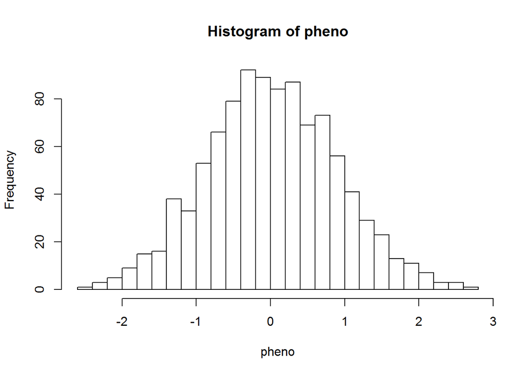

- The true regression coefficients were:

```
## [1]  0.159 -0.189 -0.144
```

- Linear models:

```
##
## Call:
## lm(formula = pheno ~ Aeps + Deps + Xeps)
##
## Residuals:
##      Min       1Q   Median       3Q      Max
## -2.40874 -0.55715 -0.01649  0.55531  2.46158
##
## Coefficients:
##             Estimate Std. Error t value Pr(>|t|)
## (Intercept)  0.01708    0.02640   0.647    0.518
## Aeps         0.14107    0.02615   5.394 8.61e-08 ***
## Deps        -0.20636    0.02640  -7.817 1.37e-14 ***
## Xeps        -0.12768    0.02664  -4.793 1.90e-06 ***
## ---
## Signif. codes:  0 '***' 0.001 '**' 0.01 '*' 0.05 '.' 0.1 ' ' 1
##
## Residual standard error: 0.8342 on 995 degrees of freedom
## Multiple R-squared:  0.1022, Adjusted R-squared:  0.0995
## F-statistic: 37.76 on 3 and 995 DF,  p-value: < 2.2e-16
```

# Single-locus GRMs

- $A = p^{-1}Z_A Z_A'$
- $\Delta = p^{-1}Z_\Delta Z_\Delta'$
- $\Gamma = p^{-1}Z_\gamma Z_\gamma'$
- Calculate this using the `tcrossprod` function on the standardized vectors holding the phased coded genotypes, in script `lrt_sim_HEDOSE.R::heSim()`

```r
    aGRM <- (1 / p) * tcrossprod(Aeps) ## 'nsnps' is used in place of 'p' in the actual code
    dGRM <- (1 / p) * tcrossprod(Deps)
    xGRM <- (1 / p) * tcrossprod(Xeps)
```

```r
agtable <- table(as.vector(aGRM))
dimnames(agtable)[[1]] <- as.character(signif(as.numeric(dimnames(agtable)[[1]]), 3))
print(agtable)
```

```
##
##      -2  -0.045 0.00106  0.0471    1.91    2.09
##  129276  260680  240100  238140   70756   59049
```

```r
dgtable <- table(as.vector(dGRM))
dimnames(dgtable)[[1]] <- as.character(signif(as.numeric(dimnames(dgtable)[[1]]), 3))
print(dgtable)
```

```
##
##  -1.05 -0.955  0.912      1    1.1
## 238140 260680  70756 369376  59049
```

```r
xgtable <- table(as.vector(xGRM))
dimnames(xgtable)[[1]] <- as.character(signif(as.numeric(dimnames(xgtable)[[1]]), 3))
print(xgtable)
```

```
##
##     -2      0      2
## 120050 757901 120050
```

```r
summary(as.vector(aGRM %*% dGRM))
```

```
##     Min.  1st Qu.   Median     Mean  3rd Qu.     Max.
## -1.74199 -1.58871  0.03744  0.00000  1.66359  1.82409
```

```r
summary(diag(aGRM %*% dGRM))
```

```
##     Min.  1st Qu.   Median     Mean  3rd Qu.     Max.
## -1.58871 -1.58871 -0.03920  0.00145 -0.03920  1.82409
```

```r
summary(as.vector(aGRM %*% xGRM))
```

```
##      Min.   1st Qu.    Median      Mean   3rd Qu.      Max.
## -1.11e-16  0.00e+00  0.00e+00  0.00e+00  0.00e+00  1.11e-16
```

```r
summary(diag(aGRM %*% xGRM))
```

```
##       Min.    1st Qu.     Median       Mean    3rd Qu.       Max.
## -8.674e-19  0.000e+00  0.000e+00  0.000e+00  0.000e+00  8.674e-19
```

```r
summary(as.vector(xGRM %*% dGRM))
```

```
##       Min.    1st Qu.     Median       Mean    3rd Qu.       Max.
## -8.882e-16  0.000e+00  0.000e+00  0.000e+00  0.000e+00  8.882e-16
```

```r
summary(diag(xGRM %*% dGRM))
```

```
##    Min. 1st Qu.  Median    Mean 3rd Qu.    Max.
##       0       0       0       0       0       0
```

- Each GRM entry is generated by pairing two phased genotypes from the set $aa,\,a_{mo}A_{fa}, A_{mo}a_{fa}, AA$
  - Expected frequencies can be calculated from the matrix $n \left(\begin{matrix}q^2 \\ pq \\ pq \\ p^2 \end{matrix}\right)\left(\begin{matrix}q^2 \\ pq \\ pq \\ p^2 \end{matrix}\right)'$
  - Values in each cell can be calculated similarly, applying the outer product to
    - $\left(2pq\right)^{-1/2}\left(-2p,\,1-2p,\,2-2p\right)'$ for $A$
    - $\left(4p^2q^2\right)^{-1/2}\left(0-2p^2,\,2p - 2p^2,\,4p - 2 - 2p^2\right)'$ for $\Delta$
    - $\left(2pq\right)^{-1/2}\left(0,\,-1,\,1,\,0\right)'$ for $\Gamma$
- There will be 6 distinct $A$ values, 5 distinct $\Delta$ values, and 3 distinct $\Gamma$ values
  - In the multivariate case, the number of possible values of GRM entries increases exponentiallly

# Cross-product matrix of phenotypes

- Again in `lrt_sim::heSim()`
- This is $Y = yy'$ where the $y$’s are the scaled $n\times 1$ column vectors of phenotypes
- The trace of $Y$ is $n$ times the sample variance of the phenotype

```r
phGRM <- tcrossprod(scale(pheno, scale = FALSE))
summary(as.vector(phGRM))
```

```
##      Min.   1st Qu.    Median      Mean   3rd Qu.      Max.
## -6.788136 -0.293976  0.000037  0.000000  0.293533  7.179071
```

```r
summary(diag(phGRM))
```

```
##    Min. 1st Qu.  Median    Mean 3rd Qu.    Max.
## 0.00000 0.08265 0.34936 0.77203 0.99583 7.17907
```

## vech()

- This function is a map between a symmetric matrix and a column vector containing the diagonal and below-diagonal elements
- Regression of, say $\mathrm{vech}\left(Y\right)$ on $\mathrm{vech}\left(\Gamma\right)$ is not exactly the same as the Haseman-Elston regression because HE regression does not include the diagonal elements of $Y$ and $\Gamma$.
  - These data *are* used in the maximum-likelihood estimate
- The number of diagonal elements does not increase as fast in $n$ as does the total number of elements.

# HE Regression

- Linear regression of the below-diagonal entries of $Y$ on the below-diagonal entries of the three GRMs of coded genotypes
- Hat matrix (projection matrix into predictor space) is of dimension $\frac{1}{2}n\left(n-1)$, and the orthogonality of the GRMs means that it should be a linear combination of the particular hat matrices for each coding
- In `lrt_sim_HEDOSE.R::heSim()`, the predictors and outcomes are stored in a data frame

```r
    hedata <- data.frame(pheno = phGRM[lower.tri(phGRM)], add = aGRM[lower.tri(aGRM)], dom = dGRM[lower.tri(dGRM)], xeps = xGRM[lower.tri(xGRM)])
```

## Predictor variables

### Hat matrices

- A
- D
- G

# Problem: mothers’ and fathers’ MAF unequal

# Problem: Correlated gametes

1. Rationale and implementation
2. Example

# Problem: Heterozygotes incorrectly phased

# Next: Multiple loci